# Line Street Maps - OSM Data

Will Ball

22/12/2020

## Line Street Maps

This document explains how to create line street maps using OSM data and ggplot2. It’s based on [this great tutorial by Christian Burkhart](https://ggplot2tutor.com/streetmaps/streetmaps/).

There are four general steps required:

1. Load in the necessary packages
2. Store the data in objects
3. Plot the line objects
4. Save the plot

## The Packages

We’re using data from Open Street Map which can be downloaded using the {osmdata} package. We also need {ggplot2} and the {magrittr} forward pipe operator (`%>%`) so we might as well call the whole {tidyverse} package.Finally, some of these functions take a little while (depending on the size of the city/area you are plotting & how detailed/large the saved file is) so I’ve also loaded {beepr} which is a package with a single function, `beep()`, that you can add to the end of your code which makes a handy noise once it’s complete.

If you don’t have these packages already installed, you should use `install.packages("packagename")` before loading them using the library function.

```r
library(osmdata)
library(tidyverse)
library(beepr)
```

## The Data

First, we collect Open Street Map data on main streets, small streets and any rivers that we want to plot.

```r
area <- "Paris, France" # Insert city/area name here within speech marks

streets <- getbb(area) %>%
  opq() %>%
  add_osm_feature(key = "highway",
                  value = c("motorway", "primary",
                            "secondary", "tertiary")) %>%
  osmdata_sf()

small_streets <- getbb(area) %>%
  opq() %>%
  add_osm_feature(key = "highway",
                  value = c("residential", "living_street",
                            "unclassified",
                            "service", "footway")) %>%
  osmdata_sf()

river <- getbb(area) %>%
  opq() %>%
  add_osm_feature(key = "waterway", value = "river") %>%
  osmdata_sf()

a <- getbb(area) # Creates an object that lists the boundary box limits for the area
beep("coin")
```

## The Plot

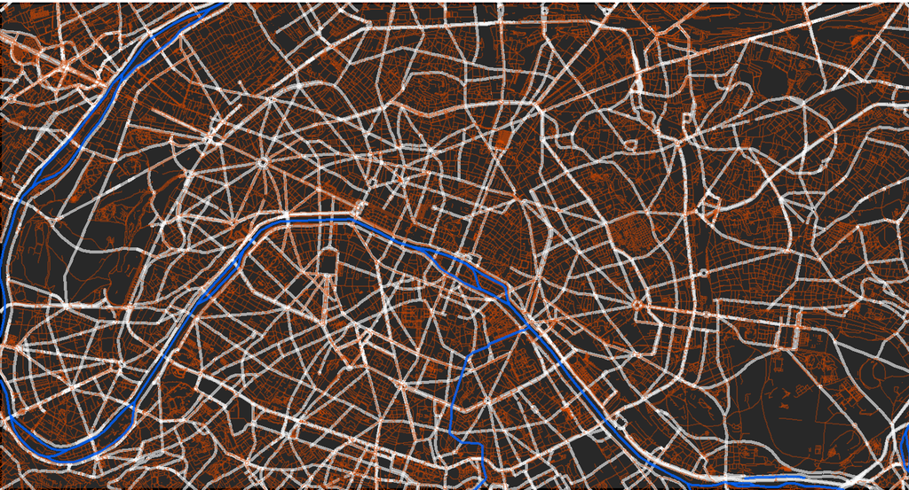

```r
(p <- ggplot() +
  geom_sf(data = streets$osm_lines,
          inherit.aes = FALSE,
          color = "white",
          size = .4,
          alpha = .6) +
  geom_sf(data = small_streets$osm_lines,
          inherit.aes = FALSE,
          color = "#D14702",
          size = .2,
          alpha = .4) +
  geom_sf(data = river$osm_lines,
          inherit.aes = FALSE,
          color = "#0062FF",
          size = .3,
          alpha = .8) +
  coord_sf(xlim = c(a[1], a[3]),
           ylim = c(a[2], a[4]),
           expand = FALSE) +
    theme_void() +
   theme(plot.background = element_rect(fill = "#282828")) # Remove this line if you want the background blank
)
beep("coin")
```

## Save

Now to save the plot. Don’t forget to change the file name.

```r
ggsave(filename = "ParisDark.png", plot = p, height = 3, width = 3, units = "in", dpi = 500)

beep("coin")
```